# Spatial Regression of Stormwater Pollutants

Christian Nilsen

#To do: *add bibilography* select a mixed effects model

#Introduction This notebook demonstrates spatial regression of stormwater pollutant data for Puget Sound. It combines stormwater outfall monitoring data with spatial regression to predict pollutant concentrations across Puget Sound.

The stormwater outfall data is available from the Department of Ecology at https://data.wa.gov/Natural-Resources-Environment/Municipal-Stormwater-Permit-Outfall-Data/d958-q2ci It uses the Socrata REST api in the form of

https://data.wa.gov/resource/d958-q2ci.json?parameter=Copper%20-%20Water%20-%20Total

Get data

```r
url <- ("https://data.wa.gov/resource/rc6b-fvgb.json")
parameter <- 'Copper - Water - Total'
#construct the SQL call
#apiCall <- paste0(url,"?$where=Result_Data_Qualifier<>'REJ' AND parameter= ","'",parameter,"'")
apiCall <- paste0(url,"?$where=parameter= ","'",parameter,"'")
data <-as_tibble(read.socrata(apiCall))
data <- (filter(data,!result_data_qualifier %in% 'REJ'))
data <- type.convert(data)
```

Looks OK

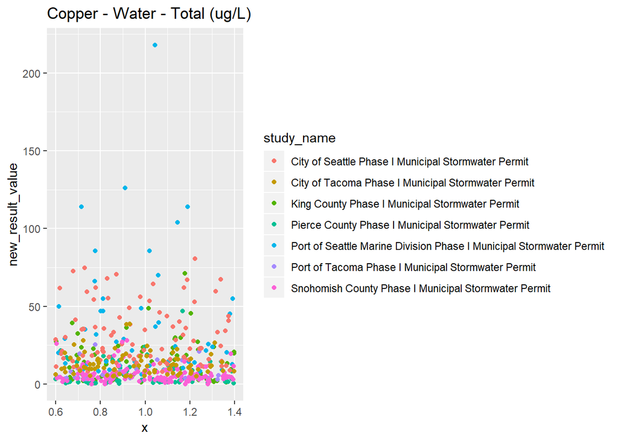

```r
#read in spatial data and join
s8data <- data %>%
  dplyr::select(location_id,study_name, parameter,season,new_result_value,nondetect_flag, new_result_units,field_collection_start_date) #sampling data
luLookup <-
 (read.csv("Data/luLookup.csv",  na = "NA")) #land use data
eeIndicies <-
  read.csv("Data/eeIndiciesNorm.csv") #spatial parameters
s8xy <-
  read.csv("Data/s8xy.csv") #xy coordinates of sampling locations

#execute join and do some fomatting
names(s8data)[1] <- "Location"
s8data <- s8data %>%
    merge(eeIndicies, by = "Location") %>%
    merge(luLookup, by = "Location") %>%
    merge(s8xy, by = "Location")
#s8data <- as_tibble(s8data)
s8data$Year <- with(s8data, format(as.Date(field_collection_start_date),"%Y"))

#Trim location names so that Port of Seattle outfall locations are the same (all same study)
s8data$Location <- substr(s8data$Location, 1, 12)
#Plot data to view
plot.title <- paste0(s8data$parameter, ' (',s8data$new_result_units,')')
plot <- ggplot(data = s8data) +
  geom_point(mapping = aes(x = 1, y = new_result_value, color = study_name), position = 'jitter')
plot+ggtitle(plot.title)
```

Looks good. Lets look at how concentration are correleated with landuse.

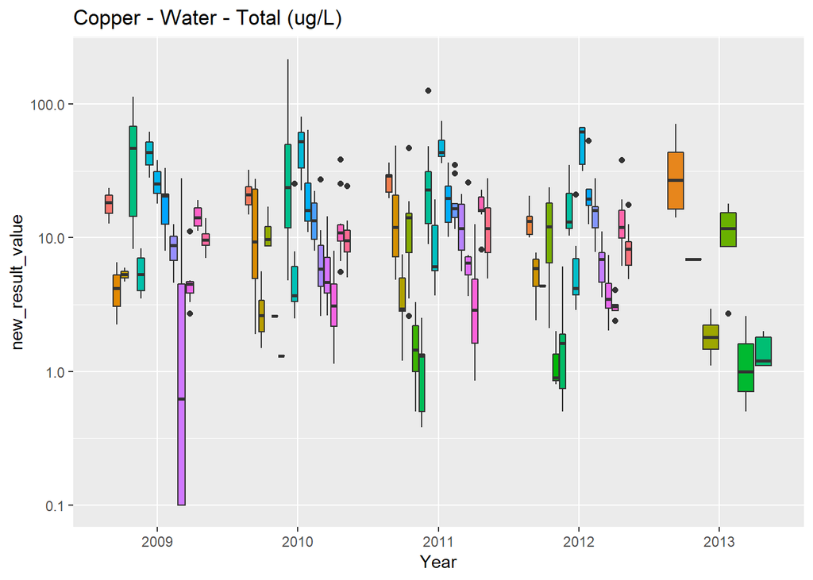

```r
s8data$Loc.Year <- paste0(s8data$Location, '-', s8data$Year)
# Box plot with dot plot
plot <- ggplot(s8data, aes(Year, new_result_value, fill = Loc.Year)) +
  geom_boxplot()+theme(legend.position = "none")+scale_y_log10()+ggtitle(plot.title)


plot
```

Since the data set has mixed detection limits, we will use the kaplan-meier estimator to evaluate median values

| site | median |
| --- | --- |
| groups=KICCOMS8D_OU | 21.00 |
| groups=KICHDRS8D_OU | 6.68 |
| groups=KICLDRS8D_OU | 2.91 |
| groups=PIECOMM_OUT | 10.80 |
| groups=PIEHIRES_OUT | 1.30 |
| groups=PIELORES_OUT | 1.30 |
| groups=POSOUTFALL_6 | 24.30 |
| groups=POT564S8D_OU | 5.62 |
| groups=SEAC1S8D_OUT | 45.90 |
| groups=SEAI1S8D_OUT | 18.20 |
| groups=SEAR1S8D_OUT | 14.80 |
| groups=SNO_COM | 7.13 |
| groups=SNO_HDR | 4.50 |
| groups=SNO_LDR | 3.13 |
| groups=TAC003S8D_OF | 14.90 |
| groups=TFWFD1 | 9.58 |

Look at landuses

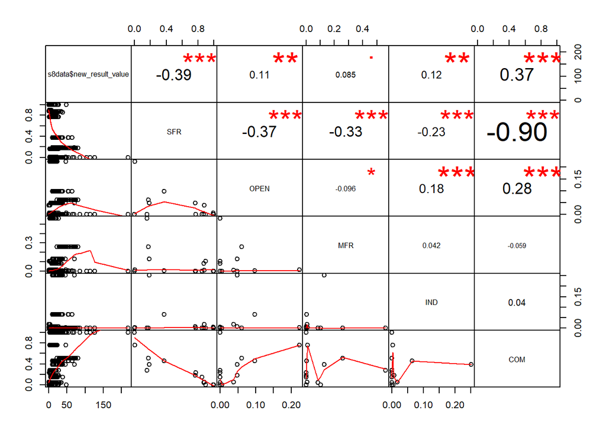

```r
cor.data <- (cbind(s8data$new_result_value, s8data[, 17:21])) #land uses
chart.Correlation(cor.data, histogram=FALSE, method = 'pearson')
```

```r
cor.matrix <- rcorr(as.matrix(cor.data),s8data$nondetect_flag)
r<- (cor.matrix$r)[,1]
P<- (cor.matrix$P)[,1]
table <- (cbind(r,P))
kable(table)
```

|  | r | P |
| --- | --- | --- |
| s8data$new_result_value | 1.0000000 | NA |
| SFR | -0.3900278 | 0.0000000 |
| OPEN | 0.1145797 | 0.0078663 |
| MFR | 0.0845119 | 0.0503057 |
| IND | 0.1160733 | 0.0070890 |
| COM | 0.3695561 | 0.0000000 |
| y | -0.1009105 | 0.0193380 |

Look at other indices

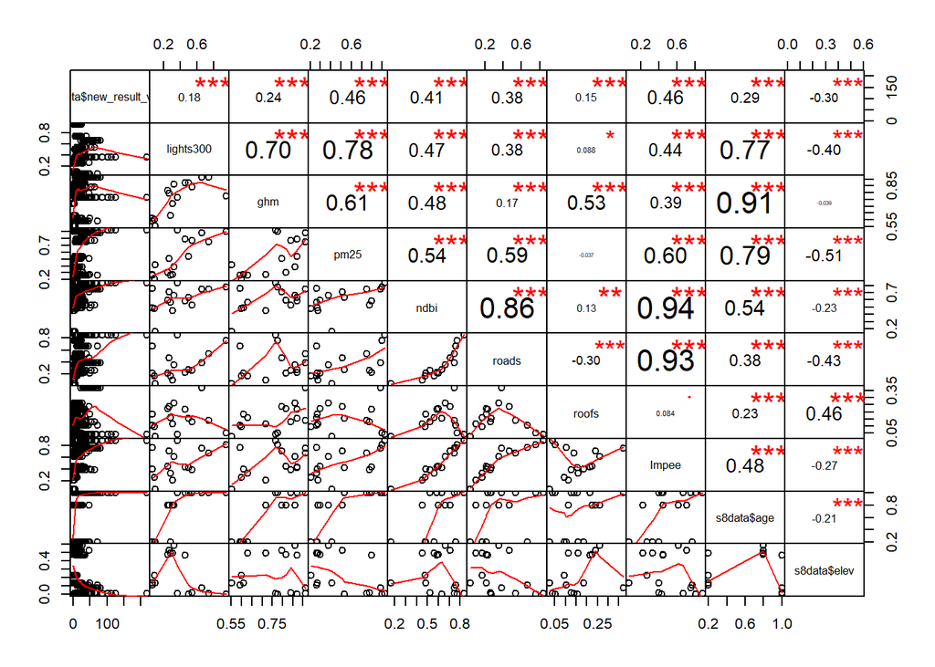

```r
cor.data <- cbind(s8data$new_result_value, s8data[, 10:16], s8data$age, s8data$elev) #indicies from earth engine
chart.Correlation(cor.data, histogram=FALSE, method = 'pearson')
```

```r
cor.matrix <- rcorr(as.matrix(cor.data),s8data$nondetect_flag)
```

```r
r<- (cor.matrix$r)[,1]
P<- (cor.matrix$P)[,1]
table <- (cbind(r,P))
kable(table)
```

[output not shown]

Begin linear model (ignore non-detects for now)

```r
library(nlme)
fit1 <- gls(new_result_value ~ COM + SFR + Impee + ndbi +roads, data=s8data,method="ML")
summary(fit1)
```

```
## Generalized least squares fit by maximum likelihood
##   Model: new_result_value ~ COM + SFR + Impee + ndbi + roads
##   Data: s8data
##        AIC      BIC    logLik
##   4593.167 4623.169 -2289.583
##
## Coefficients:
##                 Value Std.Error   t-value p-value
## (Intercept)  -9.85796  7.025498 -1.403169  0.1612
## COM          18.92509  6.742560  2.806810  0.0052
## SFR          10.76394  5.638659  1.908953  0.0568
## Impee       105.34274 17.947517  5.869488  0.0000
## ndbi        -38.45852 17.033035 -2.257878  0.0244
## roads       -49.89806 11.531015 -4.327291  0.0000
##
##  Correlation:
##       (Intr) COM    SFR    Impee  ndbi
## COM   -0.629
## SFR   -0.711  0.774
## Impee -0.139  0.349  0.585
## ndbi  -0.374 -0.064 -0.307 -0.791
## roads  0.451 -0.664 -0.489 -0.628  0.141
##
## Standardized residuals:
##         Min          Q1         Med          Q3         Max
## -1.53327976 -0.50895154 -0.08297065  0.16591433 11.04812637
##
## Residual standard error: 17.1967
## Degrees of freedom: 537 total; 531 residual
```

Begin mixed effect model

```r
#try loc and year as grouping factors
fit2 <- lme(new_result_value ~ COM + SFR + Impee + ndbi +roads, data=s8data, random = ~1|Loc.Year,method="ML")
summary(fit2)
```

```
## Linear mixed-effects model fit by maximum likelihood
##  Data: s8data
##        AIC      BIC    logLik
##   4518.305 4552.593 -2251.152
##
## Random effects:
##  Formula: ~1 | Loc.Year
##         (Intercept) Residual
## StdDev:    8.342122  14.8788
##
## Fixed effects: new_result_value ~ COM + SFR + Impee + ndbi + roads
##                 Value Std.Error  DF   t-value p-value
## (Intercept)  -4.62448 11.491236 470 -0.402436  0.6875
## COM          11.82461 10.962278  61  1.078664  0.2850
## SFR           5.99544  9.238769  61  0.648944  0.5188
## Impee       101.57998 29.454709  61  3.448684  0.0010
## ndbi        -37.13534 27.498675  61 -1.350441  0.1819
## roads       -49.35658 18.682882  61 -2.641807  0.0105
##  Correlation:
##       (Intr) COM    SFR    Impee  ndbi
## COM   -0.634
## SFR   -0.739  0.774
## Impee -0.131  0.307  0.541
## ndbi  -0.362 -0.046 -0.274 -0.794
## roads  0.406 -0.601 -0.439 -0.630  0.151
##
## Standardized Within-Group Residuals:
##         Min          Q1         Med          Q3         Max
## -2.37700154 -0.34946388 -0.09161506  0.11139867 11.95076917
##
## Number of Observations: 537
## Number of Groups: 67
```

Display ANOVA table

```r
fit3 <- lme(new_result_value ~ Impee  +roads, data=s8data, random = ~1|Loc.Year,method="ML")
summary(fit3)
```

```
## Linear mixed-effects model fit by maximum likelihood
##  Data: s8data
##        AIC      BIC    logLik
##   4515.814 4537.244 -2252.907
##
## Random effects:
##  Formula: ~1 | Loc.Year
##         (Intercept) Residual
## StdDev:    8.673682 14.87903
##
## Fixed effects: new_result_value ~ Impee + roads
##                 Value Std.Error  DF   t-value p-value
## (Intercept)  -8.28025  3.804416 470 -2.176484  0.0300
## Impee        66.93083 15.283454  64  4.379300  0.0000
## roads       -32.87679 15.007783  64 -2.190649  0.0321
##  Correlation:
##       (Intr) Impee
## Impee -0.768
## roads  0.509 -0.927
##
## Standardized Within-Group Residuals:
##        Min         Q1        Med         Q3        Max
## -2.3784195 -0.3675280 -0.1177427  0.1436309 11.9491273
##
## Number of Observations: 537
## Number of Groups: 67
```

```r
anova(fit1,fit2)
```

```
##      Model df      AIC      BIC    logLik   Test  L.Ratio p-value
## fit1     1  7 4593.167 4623.169 -2289.583
## fit2     2  8 4518.305 4552.593 -2251.152 1 vs 2 76.86196  <.0001
```

```r
library(leaps)
library(AICcmodavg)
Cand.models<-list()
Cand.models[[1]] <- fit2
Cand.models[[2]] <- fit3


#create a vector of names to trace back models in set
Modnames<-paste("mod", 1:length(Cand.models), sep="")

#generate AICc table
bictab(cand.set = Cand.models, modnames = Modnames, sort=TRUE)
```

```
##
## Model selection based on BIC:
##
##      K     BIC Delta_BIC BICWt Cum.Wt       LL
## mod2 5 4537.24      0.00     1      1 -2252.91
## mod1 8 4552.59     15.35     0      1 -2251.15
```

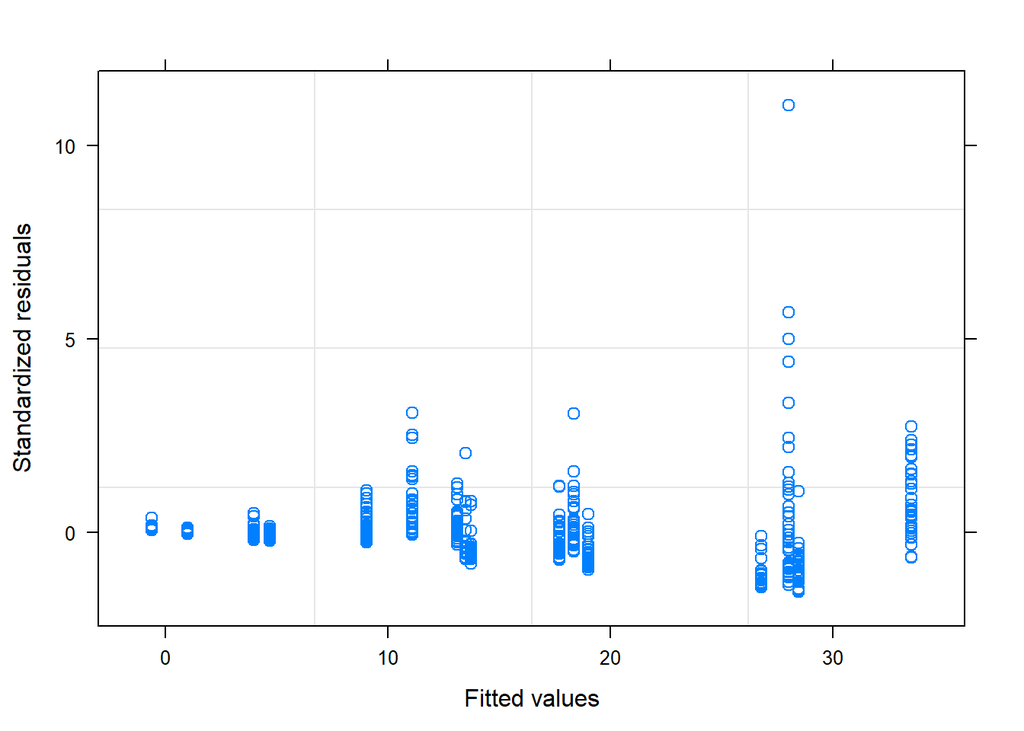

```r
plot(fit1)
```